# f_Xunif

`f_Xunif()` is a user-friendly wrapper of `standardize_GMRF()` in which popular GMRF effects can be can be specified more simply through a string in the `model` argument. The other main argument is `x`, which must contain the values of the covariate at which the basis of the effect must be evaluated (usually, the values found in the data), which will then be used in model fitting step.

The function implements some popular effects for both discrete and continuous covariates, as well as an effect for a continuous spatial covariate (i.e. $X$ is two-dimensional). For all effects, the function assumes that the covariate is Uniform distributed over a finite support, which is either specified through arguments or estimated using `x`. The object class required for `x` changes according to the `model` choice.

The argument `fixed` is present in the function but is only relevant for the case `model="iid"`.

The following table reports the effects that can be specified `f_Xunif()`, along with the additional arguments for each effect, which can either be mandatory or optional.

| `model` | Effect | Additional arguments |
| --- | --- | --- |
| `"iid"` | Cluster effect, random intercept effect for discrete covariate | `fixed`: logical, default is `FALSE` |
| `"rw1"` | Random walk effect of first order for discrete covariate |  |
| `"rw2"` | Random walk effect of second order for discrete covariate |  |
| `"besag"` | Besag or ICAR effect for areal data | `adj_mat`: square matrix (mandatory). Adjacency matrix of the lattice |
| `"linear"` | Linear effect for continuous covariate |  |
| `"pspline1"` | P-Spline effect of first order for continuous covariate | `K`: numeric (mandatory). Number of basis function |
| `"pspline2"` | P-Spline effect of second order for continuous covariate | `K`: numeric (mandatory). Number of basis function |
| `"pspline_2D"` | 2D P-Spline effect of first order for spatial data | `K`: numeric vector (mandatory). Number of basis functions in each dimension |

The output is again a list of elements that contains the same one of `standardize_GMRF()`, along with two more:

- `X_distribution`: sample of values from the Uniform distribution assumed on the covariate;
- `basis_distribution`: basis evaluated at `X_distribution` as a matrix object. These additional elements are reported to remind the user that the standardization procedure was performed assuming Uniformity rather than on the basis of the empirical distribution of `x`.

A plot showing `n_sim` realizations of the standardized process is reported along with The graphical output of `standardize_GMRF()` if `plot_check=T`.

## Discrete covariate: $X\sim \text{Unif}[1,...,K]$

Models `"iid","rw1","rw2","besag"` are effects for a discrete covariate $X\sim \text{Unif}[1,...,K]$. The `x` argument needs to be an ordered factor in which each level corresponds to a value in the support of $X$, so that $K$ is estimated as the number of levels in the factor. For all effects, the basis functions are equal to:
$$D_k(X)=\mathbb{I}(X=k)\quad
k=1,...,K$$

### `"iid"` effect

The effect assumes that the precision is an identity matrix, i.e. $\mathbf{Q}=\mathbf{I}$. This is the only effect that is affected by the fixed/random categorization.

- Fixed

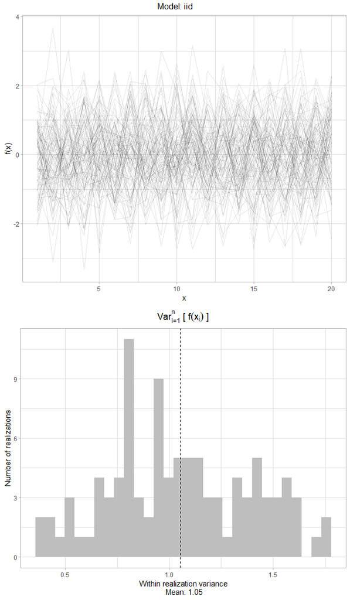

```r
K <- 20
x <- factor(1:K, ordered = TRUE, levels = c(1:K))
result <- f_Xunif(x, model = "iid",fixed=T, plot_check = TRUE)
```

- Random

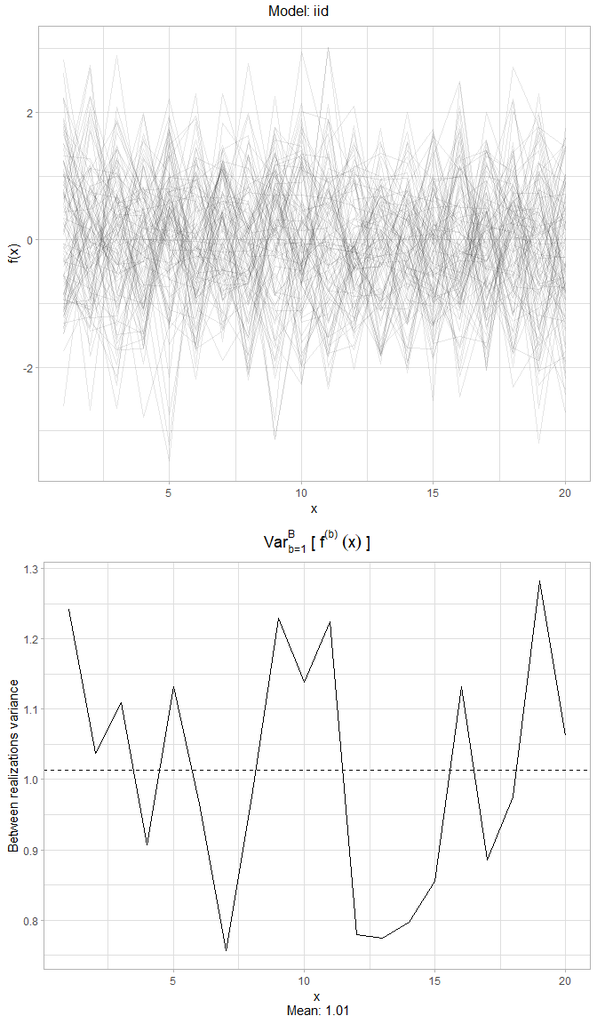

```r
result <- f_Xunif(x, model = "iid",fixed=F, plot_check = TRUE)
```

### `"rw1"` effect

`"rw1"` implements a random walk process of order 1 which is often used to model temporal effects. The model is an IGMRF of order 1 where the precision matrix is defined as:
$$\mathbf{Q}=
\begin{bmatrix}
1 & -1 & & & \\
-1 & 2 & -1 & & \\
& ... & ... & ... & \\
& & -1 & 2 & -1\\
& & & -1 & 1\\
\end{bmatrix}$$

see Equation 3.22 of Rue & Held, 2005.

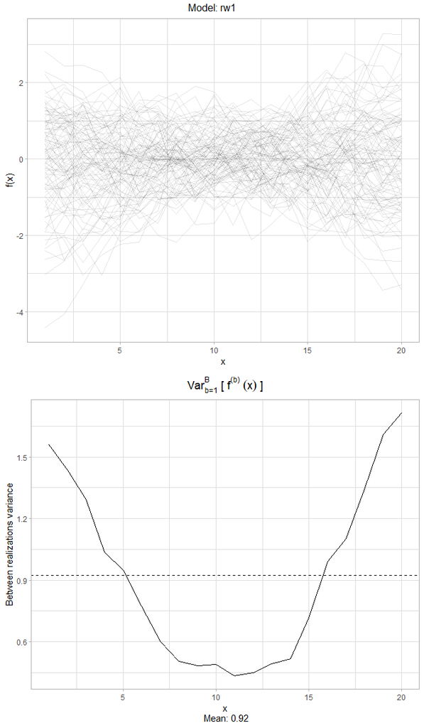

```r
result <- f_Xunif(x, model = "rw1", plot_check = TRUE)
```

### `"rw2"` effect

`"rw2"` implements a random walk process of order 2 which is often used to model temporal effects. The model is an IGMRF of order 2 where the precision matrix is defined as:
$$\mathbf{Q}=
\begin{bmatrix}
1 & -2 & 1 & & & & &
& \\
-2 & 5 & -4 & 1 & & & & &
\\
1 & -4 & 6 & -4 & 1 & & &
& \\
& 1 & -4 & 6 & -4 & 1 & &
& \\
& & ... & ... & ...&...&
...& &\\
& & & 1 & -4 & 6& -4 & 1
& \\
& & & & 1 & -4& 6 &
-4& 1 \\
& & & & & 1 & -4 & 5
& -2\\
& & & & & & 1 & -2 &
1\\
\end{bmatrix}$$
see Equation 3.40 of Rue & Held, 2005.

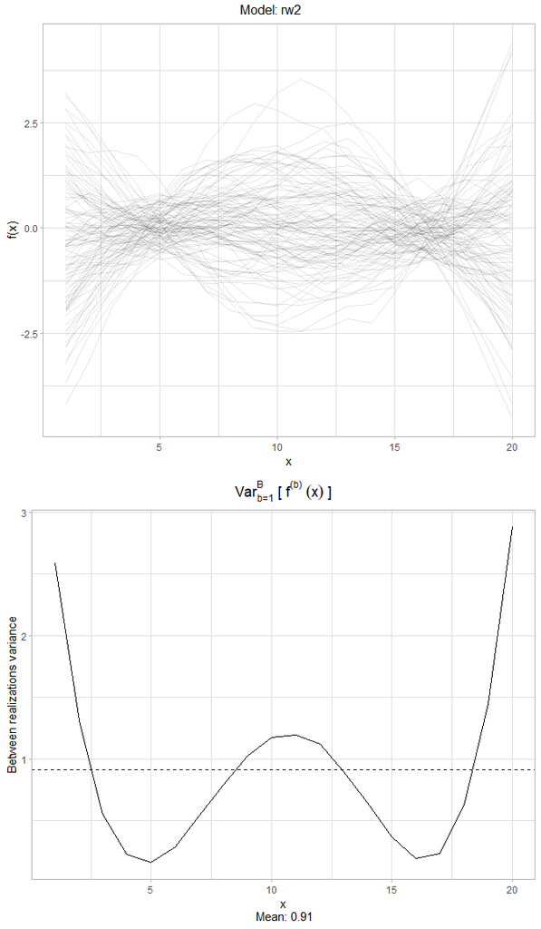

```r
result <- f_Xunif(x, model = "rw2", plot_check = TRUE)
```

### `"besag"` effect

`"besag"` implements a Besag or ICAR often used to model areal data. This effect requires the specification of the `adj_mat` argument, which must be the binary adjacency matrix between the areas of the lattice. Calling $\mathbf{W}$ the adjacency matrix, the precision matrix of the effect is defined as:
$$\mathbf{Q}=\text{diag}({\mathbf{W1}})-\mathbf{W}$$
Hence, the Besag model is an IGMRF of order 1.

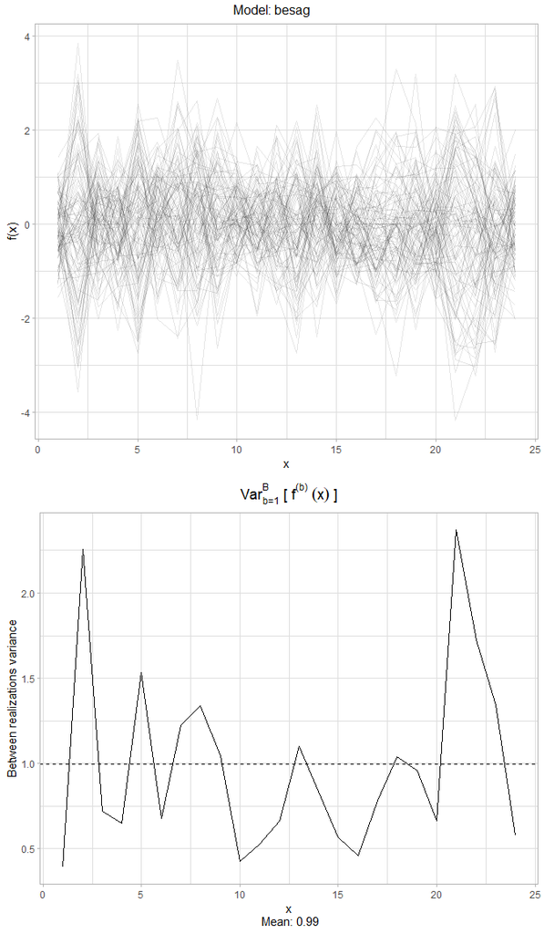

```r
data("nwEngland_adj_mat")
K <- nrow(nwEngland_adj_mat)
x <- factor(1:K, ordered = TRUE, levels = c(1:K))
result <- f_Xunif(x, model = "besag", adj_mat=nwEngland_adj_mat, plot_check = TRUE)
```

## Continuous covariate: $X\sim \text{Unif}(m,M)$

Models `"linear","pspline1","pspline2","pspline_2D"` are effects for a continuous covariate $X\sim \text{Unif}(m,M)$. The `x` argument needs to be a numeric vector. $m,M$ can be specified through arguments `m,M`; otherwise, they are estimated using the minimum and maximum of `x`.

### `"linear"` effect

A linear effect is implemented using a single basis function $D(X)=X$ and a precision matrix $\mathbf{Q}=1$.

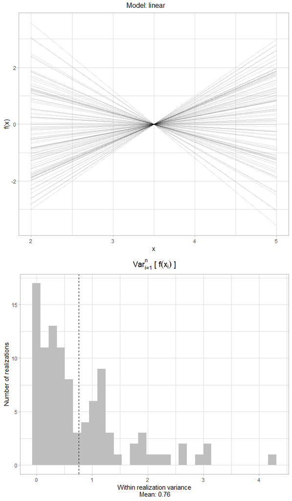

```r
x <- runif(1000, min = 2, max = 5)
result <- f_Xunif(x, model = "linear", plot_check = TRUE)
```

### `"pspline1"` effect

A P-Spline effect of order is implemented using a basis of $K$ cubic B-Spline on equidistant nodes on $m,M$ and a precision matrix equak to the one of a random walk of order 1. The number of basis functions is specified using the mandatory argument `K`.

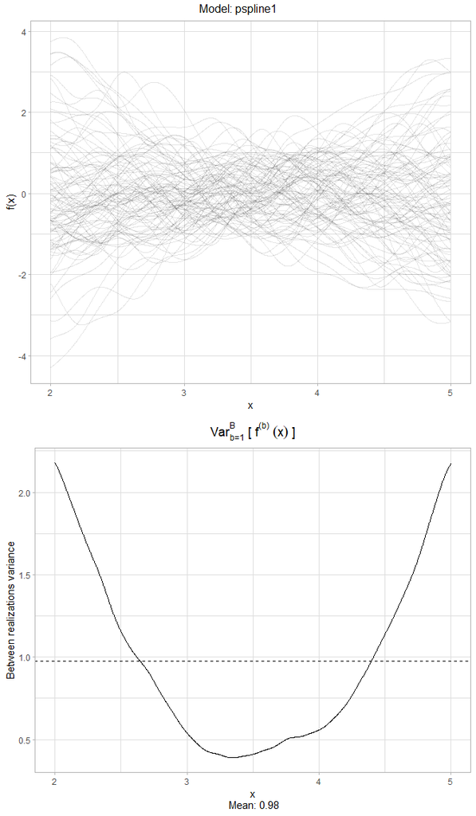

```r
K <- 20
result <- f_Xunif(x, model = "pspline1", K = K, plot_check = TRUE)
```

### `"pspline2"` effect

A P-Spline effect of order is implemented using a basis of $K$ cubic B-Spline on equidistant nodes on $m,M$ and a precision matrix equak to the one of a random walk of order 2. The number of basis functions is specified using the mandatory argument `K`.

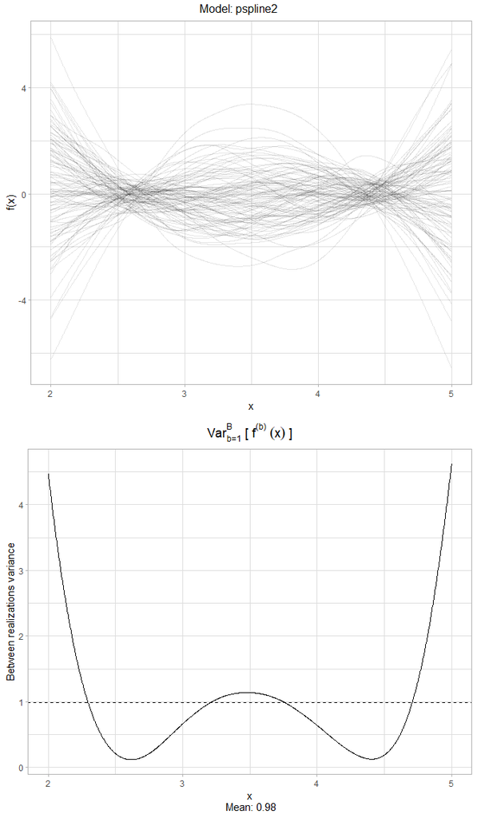

```r
K <- 20
result <- f_Xunif(x, model = "pspline2", K = K, plot_check = TRUE)
```

## Two-dimensional covariate: $X\sim \text{Unif}([m_1,M_1]x[m_2,M_2])$

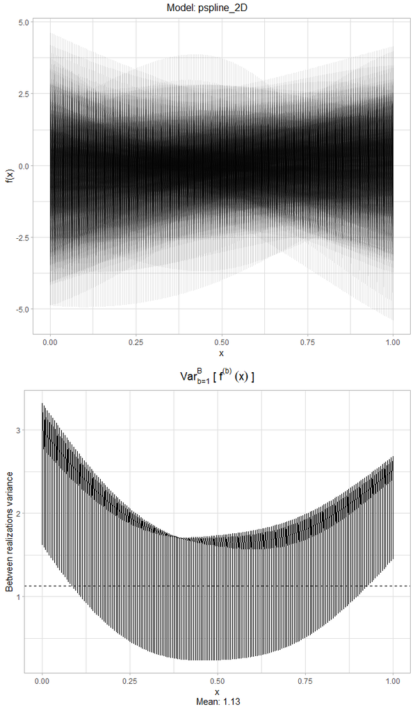

```r
x <- as.matrix(expand.grid(
  seq(0, 1, length.out = 100),
  seq(0, 1, length.out = 100)
))
result <- f_Xunif(x,model="pspline_2D", K = c(5, 5),plot_check = TRUE)
```

## References

- Rue, H., & Held, L. (2005). *Gaussian Markov random fields: theory and applications*. Chapman and Hall/CRC.